# Understand your dataset with XGBoost

TigerZ

2023-5-10

## 0.1 1 介绍

此小节的目的是向您展示如何使用 XGBoost 更好地发现和理解您自己的数据集。

此小节与预测任何内容无关（请参阅 [XGBoost presentation](https://github.com/dmlc/xgboost/blob/master/R-package/vignettes/xgboostPresentation.Rmd)）。我们将解释如何使用 XGBoost 突出显示数据特征与结果之间的联系。

加载包:

```r
require(xgboost)
require(Matrix)
require(data.table)
if (!require('vcd')) {
  install.packages('vcd')
}
```

VCD 包仅用于其嵌入式数据集之一。

## 0.2 2 准备数据集

### 0.2.1 2.1 数值和分类变量

XGBoost 仅管理 `numeric` 向量。

当你有分类数据时该怎么办？

分类变量具有固定数量的不同值。例如，如果名为 Color 的变量只能具有这三个值（红色、蓝色或绿色）中的一个，则 Color 是一个分类变量。

在 R 中，分类变量称为 `factor`。

在控制台中键入 `?factor` 以获取更多信息。

为了回答上面的问题，我们将把分类变量转换为 `numeric` 变量。

### 0.2.2 2.2 从分类变量到数值变量的转换

#### 0.2.2.1 查看原始数据

在这个小节中，我们将看到如何将具有分类变量的密集 `data.frame`（密集 = 矩阵中有很少的零）转换为数字特征的非常稀疏的矩阵（稀疏 = 矩阵中有很多零）。

我们将要看到的方法通常称为 [one-hot encoding](http://en.wikipedia.org/wiki/One-hot)。

第一步是将 `Arthritis` 数据集加载到内存中，并用 `data.table` 包对其进行包装。

```r
data(Arthritis)
df <- data.table(Arthritis, keep.rownames = FALSE)
```

`data.table` 与 R `data.frame` 100% 兼容，但其语法更加一致，并且其对大型数据集的性能是一流的（包括来自 R 的 `dplyr` 和来自 Python 的 `Pandas`）。 XGBoost R 包的某些部分使用 `data.table`。

我们要做的第一件事是查看 `data.table` 的前几行：

```r
head(df)
```

| ID | Treatment | Sex | Age | Improved |
| --- | --- | --- | --- | --- |
| 57 | Treated | Male | 27 | Some |
| 46 | Treated | Male | 29 | None |
| 77 | Treated | Male | 30 | None |
| 17 | Treated | Male | 32 | Marked |
| 36 | Treated | Male | 46 | Marked |
| 23 | Treated | Male | 58 | Marked |

```r
##    ID Treatment  Sex Age Improved
## 1: 57   Treated Male  27     Some
## 2: 46   Treated Male  29     None
## 3: 77   Treated Male  30     None
## 4: 17   Treated Male  32   Marked
## 5: 36   Treated Male  46   Marked
## 6: 23   Treated Male  58   Marked
```

现在我们将检查每一列的格式。

```r
str(df)
```

```
Classes ‘data.table’ and 'data.frame':  84 obs. of  5 variables:
 $ ID       : int  57 46 77 17 36 23 75 39 33 55 ...
 $ Treatment: Factor w/ 2 levels "Placebo","Treated": 2 2 2 2 2 2 2 2 2 2 ...
 $ Sex      : Factor w/ 2 levels "Female","Male": 2 2 2 2 2 2 2 2 2 2 ...
 $ Age      : int  27 29 30 32 46 58 59 59 63 63 ...
 $ Improved : Ord.factor w/ 3 levels "None"<"Some"<..: 2 1 1 3 3 3 1 3 1 1 ...
 - attr(*, ".internal.selfref")=<externalptr>
```

两列具有 `factor` 类型，一列具有 `ordinal` 类型。

`ordinal` 变量：

- 可以采用有限数量的值（如`factor`）；
- 这些值是有序的（与`factor`不同）。这里这些有序的值是：`Marked > Some > None`

#### 0.2.2.2 基于旧特征创建新特征

我们将添加一些新的分类特征来看看是否有帮助。

##### 0.2.2.2.1 每10年分组

对于第一个特征，我们通过四舍五入实际年龄来创建年龄组。

请注意，我们将其转换为`factor`，以便算法将这些年龄组视为独立值。

因此，20 岁并不比 60 岁更接近 30 岁。简而言之，在这种转换中，年龄之间的距离消失了。

```r
head(df[, AgeDiscret := as.factor(round(Age / 10, 0))])
```

| ID | Treatment | Sex | Age | Improved | AgeDiscret |
| --- | --- | --- | --- | --- | --- |
| 57 | Treated | Male | 27 | Some | 3 |
| 46 | Treated | Male | 29 | None | 3 |
| 77 | Treated | Male | 30 | None | 3 |
| 17 | Treated | Male | 32 | Marked | 3 |
| 36 | Treated | Male | 46 | Marked | 5 |
| 23 | Treated | Male | 58 | Marked | 6 |

##### 0.2.2.2.2 随机分成两组

以下是对真实年龄的更严格的简化，将其任意拆分为 30 岁。我没有根据地选择这个值。我们稍后会看到根据任意值简化信息是否是一个好的策略（您可能已经知道它的效果如何……）。

```r
head(df[, AgeCat := as.factor(ifelse(Age > 30, "Old", "Young"))])
```

| ID | Treatment | Sex | Age | Improved | AgeDiscret | AgeCat |
| --- | --- | --- | --- | --- | --- | --- |
| 57 | Treated | Male | 27 | Some | 3 | Young |
| 46 | Treated | Male | 29 | None | 3 | Young |
| 77 | Treated | Male | 30 | None | 3 | Young |
| 17 | Treated | Male | 32 | Marked | 3 | Old |
| 36 | Treated | Male | 46 | Marked | 5 | Old |
| 23 | Treated | Male | 58 | Marked | 6 | Old |

##### 0.2.2.2.3 添加相关特征的风险

这些新特征与 `Age` 特征高度相关，因为它们是该特征的简单转换。

对于许多机器学习算法，使用相关特征并不是一个好主意。它有时可能会使预测不太准确，并且大多数时候几乎无法解释模型。例如，GLM 假设特征是不相关的。

幸运的是，决策树算法（boosted trees）对这些特征非常稳健。因此，我们无需处理这种情况。

#### 0.2.2.3 清洗数据

我们删除了 IDs，因为从这个特征中没有什么可学习的（它只会增加一些噪声）。

```r
df[,ID:=NULL]
```

我们将列出`Treatment`列的不同值：

```r
levels(df[,Treatment])
```

```
[1] "Placebo" "Treated"
```

```r
## [1] "Placebo" "Treated"
```

#### 0.2.2.4 编码分类特征

下一步，我们将把分类数据转换为虚拟变量。存在多种编码方法，例如，[one-hot encoding](http://en.wikipedia.org/wiki/One-hot) 是一种常见的方法。我们将使用 [dummy contrast coding](https://stats.oarc.ucla.edu/r/library/r-library-contrast-coding-systems-for-categorical-variables/) ，这种编码很流行，因为它产生“full rank”编码（另请参阅 [Max Kuhn 的这篇博客文章](http://appliedpredictivemodeling.com/blog/2013/10/23/the-basics-of-encoding-categorical-data-for-predictive-models)）。

目的是将每个分类特征的每个值转换为二元特征 `{0, 1}`。

例如，`Treatment`列将替换为两列：`TreatmentPlacebo` 和 `TreatmentTreated`。他们每个都是二进制的。因此，在转换前在`Treatment`列中具有值 `Placebo` 的观察值在转换后将在新列 `TreatmentPlacebo` 中具有值 `1`，在新列 `TreatmentTreated` 中具有值 `0`。`TreatmentPlacebo` 列将在对比编码期间消失，因为它将被吸收到公共恒定截距列中。

`Improved` 列被排除在外，因为它将是我们的 `label` 列，即我们想要预测的列。

```r
sparse_matrix <- sparse.model.matrix(Improved ~ ., data = df)[, -1]
head(sparse_matrix)
```

```
6 x 9 sparse Matrix of class "dgCMatrix"
  TreatmentTreated SexMale Age AgeDiscret3 AgeDiscret4 AgeDiscret5 AgeDiscret6
1                1       1  27           1           .           .           .
2                1       1  29           1           .           .           .
3                1       1  30           1           .           .           .
4                1       1  32           1           .           .           .
5                1       1  46           .           .           1           .
6                1       1  58           .           .           .           1
  AgeDiscret7 AgeCatYoung
1           .           1
2           .           1
3           .           1
4           .           .
5           .           .
6           .           .
```

上面使用的公式 `Improved ~ .` 表示将所有分类特征除列 `Improved` 外转换为二进制值。这里的`-1`是去掉第一列全是`1`的（这一列是转换生成的）。有关详细信息，您可以在控制台中键入 `?sparse.model.matrix`。

创建输出`numeric`向量（不是稀疏矩阵）：

```r
output_vector <- df[, Improved] == "Marked"
```

1. set `Y` vector to `0`;
2. set `Y` to `1` for rows where `Improved == Marked` is `TRUE` ;
3. return `Y` vector.

## 0.3 3 建立模型

下面的代码很普通。有关详细信息，您可以查看 `xgboost` 函数的文档（或 [XGBoost presentation](https://github.com/dmlc/xgboost/blob/master/R-package/vignettes/xgboostPresentation.Rmd)）。

```r
bst <- xgboost(data = sparse_matrix, label = output_vector, max_depth = 4,
               eta = 1, nthread = 2, nrounds = 10, objective = "binary:logistic")
```

## 0.4 4 特征重要性

### 0.4.1 4.1 衡量特征重要性

#### 0.4.1.1 构建特征重要性 data.table

请记住，每个二进制列对应于一个分类特征的单个值。

```r
importance <- xgb.importance(feature_names = colnames(sparse_matrix), model = bst)
head(importance)
```

| Feature | Gain | Cover | Frequency |
| --- | --- | --- | --- |
| Age | 0.622031769 | 0.67251696 | 0.67241379 |
| TreatmentTreated | 0.285750540 | 0.11916651 | 0.10344828 |
| SexMale | 0.048744022 | 0.04522028 | 0.08620690 |
| AgeDiscret6 | 0.016604639 | 0.04784639 | 0.05172414 |
| AgeDiscret3 | 0.016373781 | 0.08028951 | 0.05172414 |
| AgeDiscret4 | 0.009270557 | 0.02858801 | 0.01724138 |

`Gain` 列提供了我们正在寻找的信息。

如您所见，特征按 `Gain` 进行分类。

`Gain` 是特征为其所在分支带来的准确性的提高。这个想法是，在将特征 X 上的新分割添加到分支之前，存在一些错误分类的元素；在这个特征上添加分割后，有两个新的分支，并且每个分支都更准确（一个分支说如果你的观察是在这个分支上那么它应该被分类为 `1`，另一个分支说完全相反）。

`Cover` 与损失函数对于特定变量的二阶导数（或 Hessian）有关；因此，较大的值表明变量对损失函数具有较大的潜在影响，因此很重要。

`Frequency` 是测量 `Gain` 的更简单的方法。它只是计算某个特征在所有生成的树中使用的次数。您不应该使用它（除非您知道为什么要使用它）。

#### 0.4.1.2 绘制特征重要性

所有这些都很好，但绘制结果会更好。

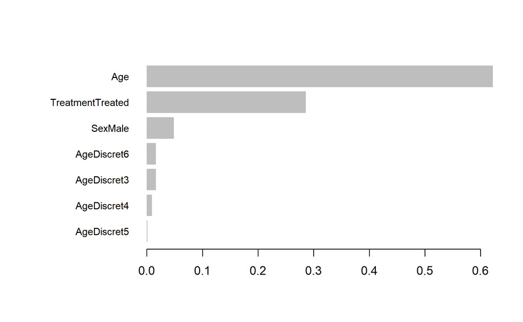

```r
xgb.plot.importance(importance_matrix = importance)
```

根据上图，该数据集中预测 treatment 是否有效的最重要特征是：

- An individual’s age;
- Having received a placebo or not;
- Gender;
- Our generated feature AgeDiscret. We can see that its contribution is very low.

#### 0.4.1.3 这些结果有意义吗？

让我们检查一下每个特征和标签之间的 `Chi2` 值。

`Chi2` 越高意味着相关性越好。

```r
c2 <- chisq.test(df$Age, output_vector)
print(c2)
```

```
    Pearson's Chi-squared test

data:  df$Age and output_vector
X-squared = 35.475, df = 35, p-value = 0.4458
```

Age 与疾病消失之间的 Pearson 相关性为 `35.47`。

```r
c2 <- chisq.test(df$AgeDiscret, output_vector)
print(c2)
```

```
    Pearson's Chi-squared test

data:  df$AgeDiscret and output_vector
X-squared = 8.2554, df = 5, p-value = 0.1427
```

我们对 Age 的第一次简化得出的 Pearson 相关系数为 `8.26`。

```r
c2 <- chisq.test(df$AgeCat, output_vector)
print(c2)
```

```
    Pearson's Chi-squared test with Yates' continuity correction

data:  df$AgeCat and output_vector
X-squared = 2.3571, df = 1, p-value = 0.1247
```

我们在 30 岁时对年轻人和老年人进行的完全随机划分的相关性较低，为 `2.36`。这表明，对于我们正在研究的特定疾病，某人易患这种疾病的年龄可能与 30 岁有很大不同。

这个故事的寓意是：不要让你的直觉降低模型的质量。